# EasyVisa Project

### Case Status and Education

#### 1. Those with higher education may want to travel abroad for a well-paid job. Does education play a role in Visa certification?

```
case_status            Certified  Denied    All
education_of_employee
All                        17001    8446  25447
Bachelor's                  6362    3858  10220
High School                 1164    2252   3416
Master's                    7565    2057   9622
Doctorate                   1910     279   2189
------------------------------------------------------------------------------------------------------------------------
```

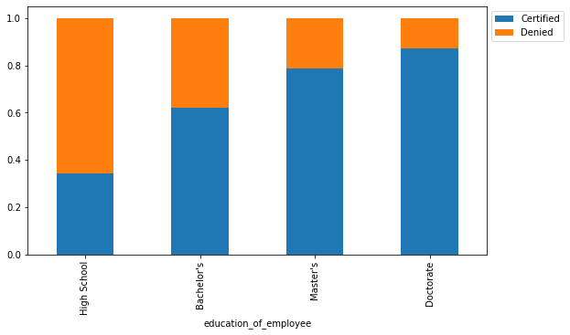

```python
stacked_barplot(data, "education_of_employee", "case_status")
```

### Case Status and Continents

#### 2. How does the visa status vary across different continents?

```
case_status    Certified  Denied    All
continent
All                17001    8446  25447
Asia               11001    5839  16840
North America       2037    1250   3287
Europe              2953     774   3727
South America        492     359    851
Africa               396     154    550
Oceania              122      70    192
------------------------------------------------------------------------------------------------------------------------
```

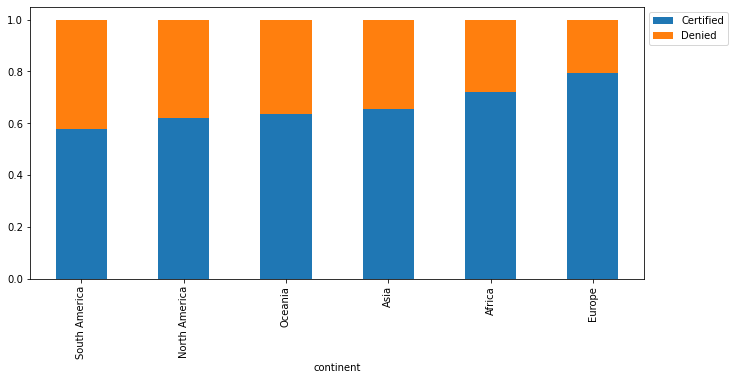

```python
stacked_barplot(data, "continent", "case_status")
```

- All continents have a higher number of Certified cases than Denied cases.
- Asia has the highest certified cases at 11001 cases, followed by Europe 2953 cases, North America 2037 cases, South America 492 cases, Africa 396 cases, and Oceania 122 cases.
- Europ has the highest approval rate ~80%, followed by Africa over 70%, Asia ~65%, Oceania ~63%, North America ~62%, and Sounth America less than 60%.
- Asia has the highest certified cases while Europe has the highest certified rate.

### Case Status and Region of Employment

```
case_status           Certified  Denied    All
region_of_employment
All                       17001    8446  25447
Northeast                  4524    2665   7189
West                       4097    2481   6578
South                      4908    2098   7006
Midwest                    3246    1053   4299
Island                      226     149    375
------------------------------------------------------------------------------------------------------------------------
```

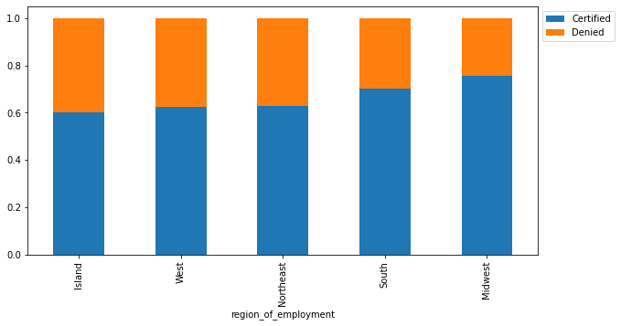

```python
stacked_barplot(data, "region_of_employment", "case_status")
```

- Midwest has the highest approval rate, ~75%.

### Case Status and Work Experience

#### 3. Experienced professionals might look abroad for opportunities to improve their lifestyles and career development. Does work experience influence visa status?

```
case_status         Certified  Denied    All
has_job_experience
All                     17001    8446  25447
N                        5986    4675  10661
Y                       11015    3771  14786
------------------------------------------------------------------------------------------------------------------------
```

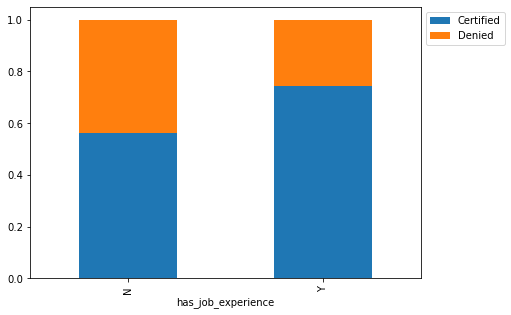

```python
stacked_barplot(data, "has_job_experience", "case_status")
```

- Applications with work experience were certified 11015 case or over 70% while applications with no working experience were certified 5986 cases or ~55%.

### Case Status and Employment Paid Intervals

#### 4. In the United States, employees are paid at different intervals. Which pay unit is most likely to be certified for a visa?

```
case_status   Certified  Denied    All
unit_of_wage
All               17001    8446  25447
Year              16030    6903  22933
Hour                747    1406   2153
Week                169     103    272
Month                55      34     89
------------------------------------------------------------------------------------------------------------------------
```

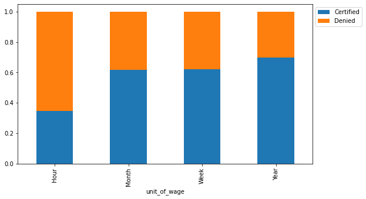

```python
stacked_barplot(data, "unit_of_wage", "case_status")
```

- The cases which has Annually employment paid interval have the highest certified cases at 16030 or ~70% approval rate.
- Weely paid interval and Monthly pain interval have over 60% approval rate.
- Hourly has the least approval rate ~35%.

### Case Status and Prevailing Wage

#### 5. The US government has established a prevailing wage to protect local talent and foreign workers. How does the visa status change with the prevailing wage?

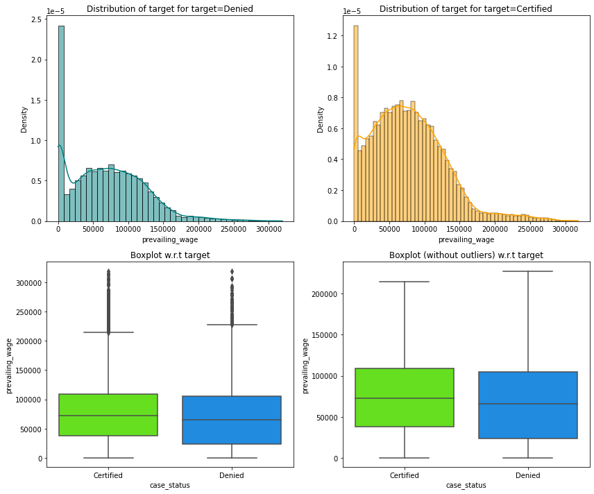

```python
distribution_plot_wrt_target(data, "prevailing_wage", "case_status")
```

- The cases that were certified have higher prevailing wage than The cases that were denied.
- Both certified and denied cases have lot of outliers.
- However we decided to not work on outliers as there are real values.

### Case Status and Full-Time Employment

```
case_status         Certified  Denied    All
full_time_position
All                     17001    8446  25447
Y                       15146    7595  22741
N                        1855     851   2706
------------------------------------------------------------------------------------------------------------------------
```

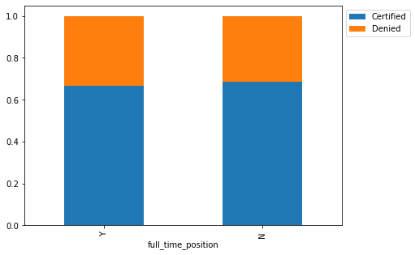

```python
stacked_barplot(data, "full_time_position", "case_status")
```

- Both full-time cases and part-time/contract cases have similar approval rate of arounf 70%.

### Case Status and Job Training

```
case_status            Certified  Denied    All
requires_job_training
All                        17001    8446  25447
N                          15000    7498  22498
Y                           2001     948   2949
------------------------------------------------------------------------------------------------------------------------
```

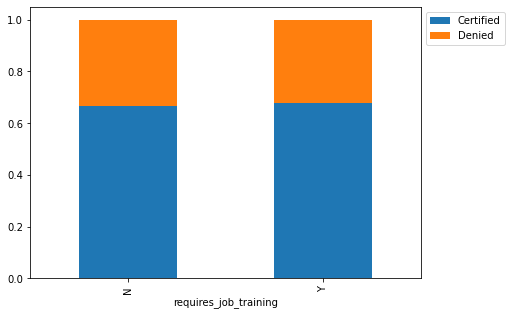

```python
stacked_barplot(data, "requires_job_training", "case_status")
```

### Case Status and Year of Employeer's was Established

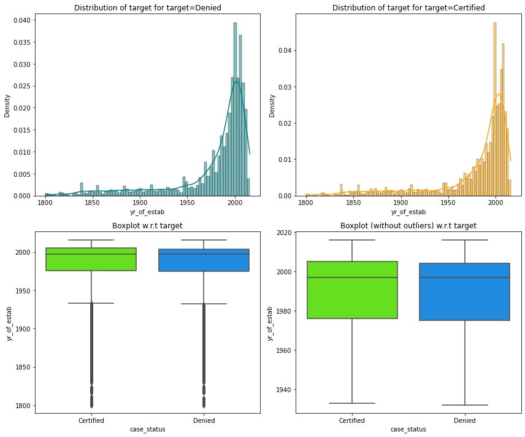

```python
distribution_plot_wrt_target(data, "yr_of_estab", "case_status")
```

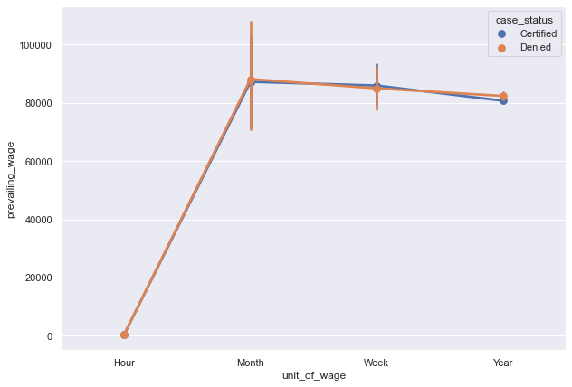

```python
sns.set(rc={'figure.figsize':(10,7)})
sns.pointplot(data = data, x = 'unit_of_wage', y = 'prevailing_wage', hue = 'case_status');
```

- Those case statuses as certified and as denied have very similar prevalling wages in hourly wage, monthly wage, weekly rage and annully rate.
- However, the denied case with monthly paid group has a larger range of prevaling wage than other group.

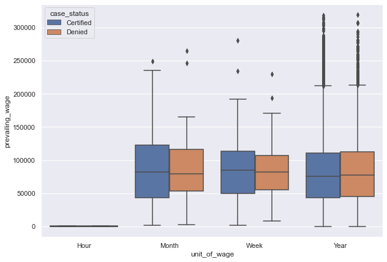

```python
sns.set(rc={'figure.figsize':(10,7)})
sns.boxplot(data = data, x = 'unit_of_wage', y = 'prevailing_wage', hue = 'case_status');
```

- Those paid annully cases, Certified or Denied have quite similar `prevailing_wage` with lot of outliers.